# Ri_Liu_Case_Study_2

Ri Liu

4/9/2022

There is 1 dataset(csv) with 3 years worth of customer orders. There are 4 columns in the csv dataset: index, CUSTOMER_EMAIL(unique identifier as hash), Net_Revenue, and Year. For each year we need the following information:

• Revenue lost from attrition • Existing Customer Revenue Current Year • Existing Customer Revenue Prior Year • Total Customers Current Year • Total Customers Previous Year • New Customers • Lost Customers

```r
# packages
library(dplyr)
library(ggplot2)
```

```r
# read data
data <- read.csv('casestudy.csv')
```

## Customer Analysis

### Total customers

```r
# total customers in 2015
customer_2015 <- data %>%
  filter(year == 2015) %>%
  select(customer_email) %>%
  distinct()
paste('Total customers in 2015: ', dim(customer_2015)[1])
```

```
## [1] "Total customers in 2015:  231294"
```

```r
# total customers in 2016
customer_2016 <- data %>%
  filter(year == 2016) %>%
  select(customer_email) %>%
  distinct()
paste('Total customers in 2016: ', dim(customer_2016)[1])
```

```
## [1] "Total customers in 2016:  204646"
```

```r
# total customers in 2017
customer_2017 <- data %>%
  filter(year == 2017) %>%
  select(customer_email) %>%
  distinct()
paste('Total customers in 2017: ', dim(customer_2017)[1])
```

```
## [1] "Total customers in 2017:  249987"
```

```r
(dim(customer_2017)[1] - dim(customer_2016)[1]) / dim(customer_2016)[1] * 100
```

```
## [1] 22.15582
```

### Existing Customers

```r
# existing customers in 2016
existingCustomer_2016 <- inner_join(customer_2015, customer_2016, "customer_email")
paste('Existing customers in 2016: ', dim(existingCustomer_2016)[1])
```

```
## [1] "Existing customers in 2016:  59584"
```

```r
# existing customers in 2015 and 2016
customer_1516 <- distinct(rbind(customer_2015, customer_2016))

# existing customers in 2017
existingCustomer_2017 <- inner_join(customer_2017, customer_1516, "customer_email")
paste('Existing customers in 2017: ', dim(existingCustomer_2017)[1])
```

```
## [1] "Existing customers in 2017:  21725"
```

### New Customers

```r
# new customers in 2016
newCustomer_2016 <- data %>%
  filter(year == 2016 & !customer_email %in% existingCustomer_2016[[1]]) %>%
  select(customer_email)
paste('New customers in 2016: ', dim(newCustomer_2016)[1])
```

```
## [1] "New customers in 2016:  145062"
```

```r
# new customers in 2017
newCustomer_2017 <- data %>%
  filter(year == 2017 & !customer_email %in% existingCustomer_2017[[1]]) %>%
  select(customer_email)
paste('New customers in 2017: ', dim(newCustomer_2017)[1])
```

```
## [1] "New customers in 2017:  228262"
```

```r
# new customer (number) growth rate 2016 to 2017
paste('New customers growth rate 2016 to 2017: ', round((dim(newCustomer_2017)[[1]] - dim(newCustomer_2016)[[1]]) / dim(newCustomer_2016)[[1]] * 100, 2), '%')
```

```
## [1] "New customers growth rate 2016 to 2017:  57.35 %"
```

### Lost Customers

```r
paste('Lost customers 2016-2017: ', abs(dim(existingCustomer_2016)[[1]] - dim(existingCustomer_2017)[[1]]))
```

```
## [1] "Lost customers 2016-2017:  37859"
```

```r
# customer lost rate 2016 to 2017
(dim(existingCustomer_2016)[[1]] - dim(existingCustomer_2017)[[1]]) / dim(existingCustomer_2016)[[1]] * 100
```

```
## [1] 63.53887
```

```r
# add a column to denote as existing or new customers
data$New_Customer <- NA
data[data$year == 2016, ] <- data %>%
  filter(year == 2016) %>%
  mutate(New_Customer = if_else(customer_email %in% existingCustomer_2016[[1]], 'Existing Customer', 'New Customer'))
data[data$year == 2017, ] <- data %>%
  filter(year == 2017) %>%
  mutate(New_Customer = if_else(customer_email %in% existingCustomer_2017[[1]], 'Existing Customer', 'New Customer'))
```

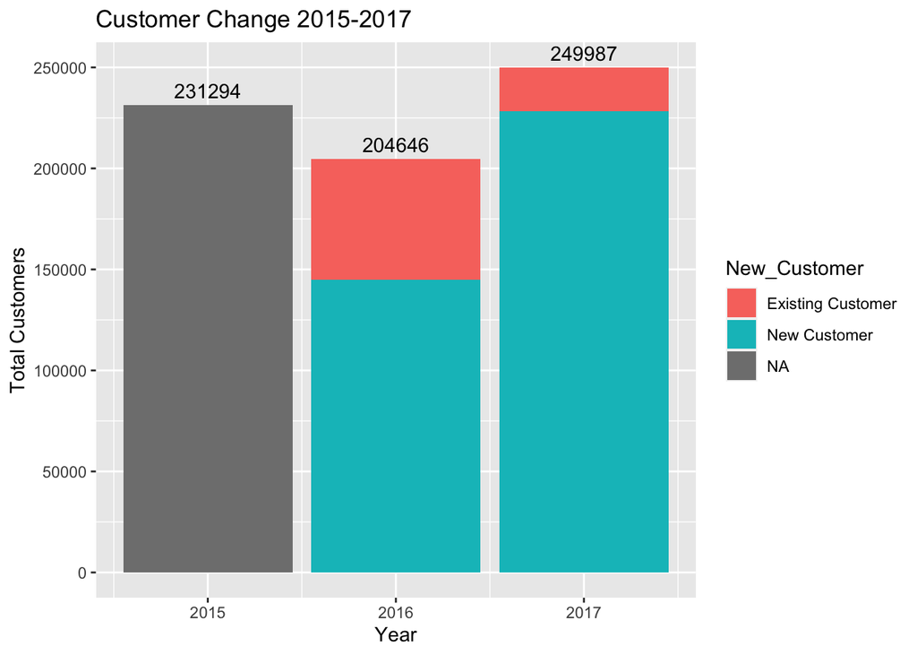

```r
ggplot(data = data,
       aes(x = year)) +
  geom_bar(position = 'stack', aes(fill = New_Customer)) +
  geom_text(stat='count', aes(label=..count..), vjust = -0.5) +
  labs(title = 'Customer Change 2015-2017',
       x = 'Year',
       y = 'Total Customers')
```

From 2016 to 2017, we lost 37859 (63.54%) existing customers. But we gained 57.35% more new customers. And our total yearly active customer had a 22.16% increase, from 204646 to 249987. It is also higher in 2017 compared with 2015. There might be an action from 2016 to 2017 to reverse the downward trend of total number of customers. And we can see that there is a larger number and proportion of new customers in 2017. But the decrease of number of existing customer suggests that the action probably affected existing customers’ experience.

## Revenue Analysis

### Total revenue for the current year

```r
# total revenue in each year and yearly growth rate
totalRevenue <- data %>%
  group_by(year) %>%
  summarise('Total revenue for the current year' = sum(net_revenue)) %>%
  mutate('Revenue Growth Rate(%)' = (.[,2, drop=T] - lag(.[,2,drop=T])) / lag(.[,2,drop=T]) * 100)
totalRevenue
```

```
## # A tibble: 3 × 3
##    year `Total revenue for the current year` `Revenue Growth Rate(%)`
##   <int>                                <dbl>                    <dbl>
## 1  2015                            29036749.                     NA
## 2  2016                            25730944.                    -11.4
## 3  2017                            31417495.                     22.1
```

### New Customer Revenue

```r
# new customer revenue in 2016
new_revenue_2016 <- data %>%
  filter(year == 2016 & !customer_email %in% existingCustomer_2016[[1]]) %>%
  summarise('New Customer Revenue in 2016' = sum(net_revenue))
new_revenue_2016
```

```
##   New Customer Revenue in 2016
## 1                     18245491
```

```r
# new customer revenue in 2017
new_revenue_2017 <- data %>%
  filter(year == 2017 & !customer_email %in% existingCustomer_2017[[1]]) %>%
  summarise('New Customer Revenue in 2017' = sum(net_revenue))
new_revenue_2017
```

```
##   New Customer Revenue in 2017
## 1                     28676608
```

```r
paste('New Customer Growth Rate 2016-2017: ',
      round((new_revenue_2017[[1]] - new_revenue_2016[[1]]) / new_revenue_2016[[1]] * 100, 2),
      '%')
```

```
## [1] "New Customer Growth Rate 2016-2017:  57.17 %"
```

### Existing Customer Revenue

- 2016

```r
# existing customer revenue in 2016
existing_revenue_2016 <- data %>%
  filter(year == 2016 & customer_email %in% existingCustomer_2016[[1]]) %>%
  summarise(sum(net_revenue))
paste('Existing customer revenue in 2016: ', round(existing_revenue_2016[[1]], 2))
```

```
## [1] "Existing customer revenue in 2016:  7485452.58"
```

- 2017

```r
# new customer revenue in 2017
existing_revenue_2017 <- data %>%
  filter(year == 2017 & customer_email %in% existingCustomer_2017[[1]]) %>%
  summarise(sum(net_revenue))
paste('Existing customer revenue in 2016: ', round(existing_revenue_2017[[1]], 2))
```

```
## [1] "Existing customer revenue in 2016:  2740887.39"
```

### Existing Customer (Revenue) Growth

```r
# existing customer revenue growth 2016-2017
paste('Existing Customer Growth 2016-2017: ',
      existing_revenue_2017[[1]] - existing_revenue_2016[[1]])
```

```
## [1] "Existing Customer Growth 2016-2017:  -4744565.19"
```

```r
# existing customer revenue growth rate 2016-2017
paste('Existing Customer Growth Rate 2016-2017: ',
      round((existing_revenue_2017[[1]] - existing_revenue_2016[[1]]) / existing_revenue_2016[[1]] * 100, 2),
      '%')
```

```
## [1] "Existing Customer Growth Rate 2016-2017:  -63.38 %"
```

### Revenue lost from attrition

```r
revenueLost_2016 <- totalRevenue[1, 2, drop=T] - totalRevenue[2, 2, drop=T]
paste('Revenue Attrition 2015-2016: ', round(revenueLost_2016, 2))
```

```
## [1] "Revenue Attrition 2015-2016:  3305805.6"
```

```r
attritionRate_2016 <- revenueLost_2016 / totalRevenue[1, 2, drop=T] * 100
paste('Revenue Attrition Rate 2015-2016: ', round(attritionRate_2016, 2), '%')
```

```
## [1] "Revenue Attrition Rate 2015-2016:  11.38 %"
```

```r
revenueLost_2017 <- totalRevenue[2, 2, drop=T] - totalRevenue[3, 2, drop=T]
paste('Revenue Attrition 2016-2017: ', round(revenueLost_2017, 2))
```

```
## [1] "Revenue Attrition 2016-2017:  -5686551.44"
```

```r
attritionRate_2017 <- revenueLost_2017 / totalRevenue[2, 2, drop=T] * 100
paste('Revenue Attrition Rate 2016-2017: ', round(attritionRate_2017, 2), '%')
```

```
## [1] "Revenue Attrition Rate 2016-2017:  -22.1 %"
```

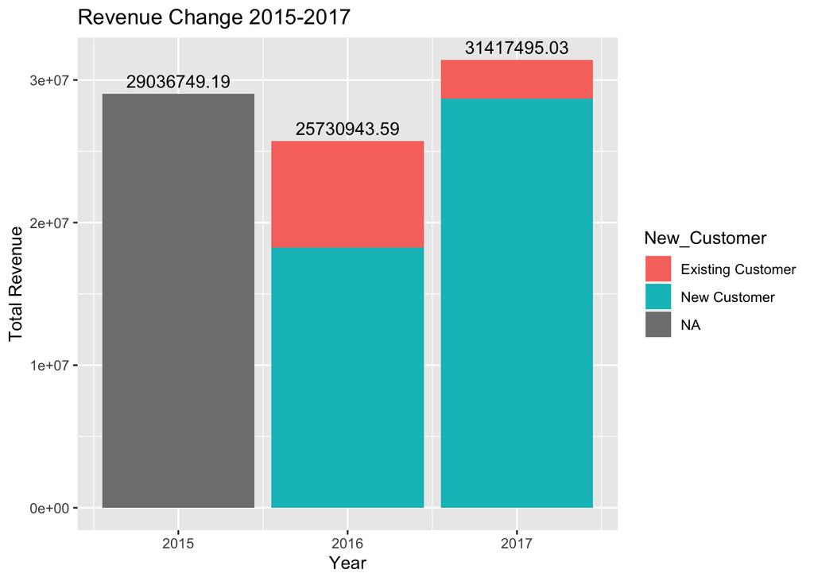

```r
ggplot(data, aes(year, net_revenue)) +
  geom_col(aes(fill = New_Customer)) +
  stat_summary(
    aes(label = stat(round(y,2))), fun = 'sum', geom = 'text', vjust = -0.5
  ) +
  labs(title = 'Revenue Change 2015-2017',
       x = 'Year',
       y = 'Total Revenue')
```